# Alpha_Diversity

### Introduction

The alpha diversity of cloacal microbiome data from influenza A–infected mallard ducks was analyzed using the Shannon and Faith’s diversity metrics. The code for this analysis was adapted from UBC MICB 305 and MICB 205 course material.

Loading the packages needed for Alpha diversity measures and statistical analysis.

```r
library(tidyverse)
library(phyloseq)
library(vegan)
library(picante)
library(ape)
library(dunn.test)
library(ggsignif)
```

Importing processed phyloseq object from generate_phyloseq.Rmd

```r
ps <- readRDS('../processed_data/phyloseq_taxonomy.rds')
```

Rarefying the data.

```r
psrare= ps %>% rarefy_even_depth(sample.size = 5396, rngseed = 360)
```

```
## `set.seed(360)` was used to initialize repeatable random subsampling.
```

```
## Please record this for your records so others can reproduce.
```

```
## Try `set.seed(360); .Random.seed` for the full vector
```

```
## ...
```

```
## 4 samples removedbecause they contained fewer reads than `sample.size`.
```

```
## Up to first five removed samples are:
```

```
## SRR5275080SRR5275088SRR5275119SRR5275137
```

```
## ...
```

```
## 237OTUs were removed because they are no longer
## present in any sample after random subsampling
```

```
## ...
```

```r
#The rarefraction depth was decided based on qiime 2 outputs
```

### Shannon’s Diversity Index

## HA and NA

Calculating the Shannon diversity metric.

```r
set.seed(360)
p = plot_richness(psrare, x="HA_NA",
                        measures = c("Shannon"),
                  color= "HA_NA")
pdata = p$data
#Extracting Shannon diversity
```

Statistical analysis of the shannon diversity metric between subtypes.

```r
df <- data.frame(HA_NA = as.factor(pdata$HA_NA), value = pdata$value)
#Kruskal-Wallis and Dunn's test as post-hoc
res_sig <-dunn.test(df$value, df$HA_NA, kw=TRUE, method = "bh")
```

```
##   Kruskal-Wallis rank sum test
##
## data: x and group
## Kruskal-Wallis chi-squared = 15.7751, df = 12, p-value = 0.2
##
##
##                    Dunn's Pairwise Comparison of x by group
##                              (Benjamini-Hochberg)
## Col Mean-│
## Row Mean │       H2N3   H3.4N2.8       H3N8       H4N1       H4N2     H4N2.6
## ─────────┼──────────────────────────────────────────────────────────────────
## H3.4N2.8 │  -0.684692
##          │     0.4583
##          │
##     H3N8 │  -0.061544   0.667928
##          │     0.4945     0.4573
##          │
##     H4N1 │  -0.245317   0.329531  -0.221741
##          │     0.4913     0.4742     0.4872
##          │
##     H4N2 │  -0.132633   0.507346  -0.099204   0.126836
##          │     0.4984     0.4419     0.4854     0.4939
##          │
##   H4N2.6 │   1.395014   1.559780   1.444024   1.230249   1.293733
##          │     0.5779     0.5792     0.5801     0.5015     0.5090
##          │
##     H4N6 │   1.524398   1.340930   1.762946   0.888033   1.014569  -0.802782
##          │     0.5521     0.5398     1.0000     0.4712     0.4655     0.4703
##          │
##     H4N8 │  -0.270179   0.418560  -0.240662   0.038050  -0.108739  -1.382518
##          │     0.4951     0.4391     0.4859     0.4976     0.4880     0.5421
##          │
##     H4N9 │  -0.919025  -0.175749  -0.905895  -0.505280  -0.710284  -1.735530
##          │     0.4988     0.4935     0.4909     0.4349     0.4542     0.8058
##          │
##     H5N1 │   0.437344   0.890551   0.515280   0.465128   0.423326  -1.123116
##          │     0.4450     0.4851     0.4462     0.4392     0.4442     0.5365
##          │
##     H5N2 │   0.734731   1.022174   0.867720   0.575987   0.580529  -1.089778
##          │     0.4747     0.4984     0.4699     0.4318     0.4380     0.5122
```

[output cut: 14 more lines]

```
##          │
##     H5N1 │  -0.794610   0.553295   1.117443
##          │     0.4624     0.4350     0.5144
##          │
##     H5N2 │  -0.806765   0.721987   1.260140   0.170712
##          │     0.4815     0.4585     0.5061     0.4886
##          │
##     H5N5 │  -0.647971   0.786141   1.306358   0.266598   0.123466
##          │     0.4583     0.4551     0.5333     0.4889     0.4884
##          │
##      neg │  -3.075756  -0.027730   0.732221  -1.019638  -1.693606  -1.783501
##          │     0.0819     0.4953     0.4640     0.4803     0.7047     1.0000
##
## FDR = 0.05
## Reject Ho if p ≤ FDR/2 with stopping rule, where p = Pr(Z ≥ |z|)
```

## NA Not Aggregated

Shannon diversity calculation but grouped by NA subtype.

```r
set.seed(360)
p_NA_shannon = plot_richness(psrare, x="na_subtype",
                        measures = c("Shannon"),
                  color= "na_subtype")

pdata_NA_shannon = p_NA_shannon$data
```

Statistical analysis of the shannon diversity metric between NA subtypes.

```r
df_NA_shannon <- data.frame(na_subtype = as.factor(pdata_NA_shannon$na_subtype), value = pdata_NA_shannon$value)
#Kruskal-Wallis and Dunn's test as post-hoc
res_sig_NA <-dunn.test(df_NA_shannon$value, df_NA_shannon$na_subtype, kw=TRUE,
                    method = "bh")
```

```
##   Kruskal-Wallis rank sum test
##
## data: x and group
## Kruskal-Wallis chi-squared = 13.8144, df = 9, p-value = 0.13
##
##
##                    Dunn's Pairwise Comparison of x by group
##                              (Benjamini-Hochberg)
## Col Mean-│
## Row Mean │          1          2        2.6        2.8          3          5
## ─────────┼──────────────────────────────────────────────────────────────────
##        2 │   0.219515
##          │     0.4426
##          │
##      2.6 │   1.217668   1.162989
##          │     0.3866     0.3443
##          │
##      2.8 │  -0.824563  -0.962632  -1.559780
##          │     0.3292     0.3434     0.4455
##          │
##        3 │  -0.304417  -0.606966  -1.395014   0.684692
##          │     0.4280     0.3496     0.3668     0.3470
##          │
##        5 │   0.255442   0.060624  -1.120017   0.972647   0.615407
##          │     0.4381     0.4758     0.3477     0.3544     0.3562
##          │
##        6 │   1.030152   1.033647  -0.802782   1.340930   1.524398   0.860066
##          │     0.3408     0.3568     0.3166     0.3374     0.4095     0.3508
##          │
##        8 │  -0.448715  -0.840838  -1.480796   0.644825  -0.126977  -0.821191
##          │     0.3870     0.3465     0.3467     0.3539     0.4597     0.3193
##          │
##        9 │  -1.054673  -1.202139  -1.735530  -0.175749  -0.919025  -1.208440
##          │     0.3645     0.3440     0.6199     0.4503     0.3503     0.3646
##          │
##      neg │  -0.830513  -1.483398  -1.658075   0.521986  -0.513434  -1.353321
##          │     0.3385     0.3880     0.5473     0.3760     0.3695     0.3599
## Col Mean-│
## Row Mean │          6          8          9
## ─────────┼─────────────────────────────────
##        8 │  -1.928788
##          │     0.6048
##          │
##        9 │  -1.582475  -0.884332
##          │     0.5109     0.3530
##          │
##      neg │  -2.962649  -0.444266   0.767627
##          │     0.0686     0.3790     0.3213
##
## FDR = 0.05
## Reject Ho if p ≤ FDR/2 with stopping rule, where p = Pr(Z ≥ |z|)
```

## HA Not Aggregated

Shannon diversity calculation but grouped by HA subtype.

```r
set.seed(360)
p_HA_shannon = plot_richness(psrare, x="ha_subtype",
                        measures = c("Shannon"),
                  color= "ha_subtype")

pdata_HA_shannon = p_HA_shannon$data
```

Statistical analysis of the shannon diversity metric between HA subtypes.

```r
df_HA_shannon <- data.frame(ha_subtype = as.factor(pdata_HA_shannon$ha_subtype), value = pdata_HA_shannon$value)
#Kruskal-Wallis and Dunn's test as post-hoc
res_sig_HA <-dunn.test(df_HA_shannon$value, df_HA_shannon$ha_subtype, kw=TRUE,
                    method = "bh")
```

```
##   Kruskal-Wallis rank sum test
##
## data: x and group
## Kruskal-Wallis chi-squared = 9.9086, df = 5, p-value = 0.08
##
##
##                    Dunn's Pairwise Comparison of x by group
##                              (Benjamini-Hochberg)
## Col Mean-│
## Row Mean │          2          3        3.4          4          5
## ─────────┼───────────────────────────────────────────────────────
##        3 │  -0.061544
##          │     0.4755
##          │
##      3.4 │  -0.684692  -0.667928
##          │     0.4113     0.3781
##          │
##        4 │   1.093965   1.305120   1.149139
##          │     0.4110     0.4796     0.4697
##          │
##        5 │   0.851938   1.037137   1.050653  -0.360927
##          │     0.3696     0.3211     0.3668     0.3847
##          │
##      neg │  -0.604580  -0.603961   0.486650  -2.646869  -2.305994
##          │     0.3719     0.3412     0.3614     0.0609     0.0792
##
## FDR = 0.05
## Reject Ho if p ≤ FDR/2 with stopping rule, where p = Pr(Z ≥ |z|)
```

## NA Subtype Aggregated

Shannon diversity calculation but grouped by NA subtype with aggregated sub-subtype—–>subtype.

```r
set.seed(360)
p_NA_aggr_shannon = plot_richness(psrare, x="na_aggr",
                        measures = c("Shannon"),
                  color= "na_aggr")

pdata_NA_aggr_shannon = p_NA_aggr_shannon$data
```

Statistical analysis of the shannon diversity metric between NA aggregated subtypes

```r
df_NA_aggr_shannon <- data.frame(na_aggr = as.factor(pdata_NA_aggr_shannon$na_aggr), value = pdata_NA_aggr_shannon$value)
#Kruskal-Wallis and Dunn's test as post-hoc
res_sig_aggr_NA <-dunn.test(df_NA_aggr_shannon$value, df_NA_aggr_shannon$na_aggr, kw=TRUE, method = "bh")
```

```
##   Kruskal-Wallis rank sum test
##
## data: x and group
## Kruskal-Wallis chi-squared = 11.3628, df = 7, p-value = 0.12
##
##
##                    Dunn's Pairwise Comparison of x by group
##                              (Benjamini-Hochberg)
## Col Mean-│
## Row Mean │          1          2          3          5          6          8
## ─────────┼──────────────────────────────────────────────────────────────────
##        2 │   0.252983
##          │     0.4309
##          │
##        3 │  -0.304417  -0.654656
##          │     0.4438     0.3778
##          │
##        5 │   0.255442   0.029474   0.615407
##          │     0.4471     0.4882     0.3768
##          │
##        6 │   1.030152   1.035929   1.524398   0.860066
##          │     0.3856     0.4203     0.3567     0.3638
##          │
##        8 │  -0.448715  -0.906930  -0.126977  -0.821191  -1.928788
##          │     0.4160     0.3925     0.4661     0.3389     0.3763
##          │
##        9 │  -1.054673  -1.221326  -0.919025  -1.208440  -1.582475  -0.884332
##          │     0.4536     0.4439     0.4178     0.3970     0.3974     0.3765
##          │
##      neg │  -0.830513  -1.611304  -0.513434  -1.353321  -2.962649  -0.444266
##          │     0.3555     0.4999     0.4051     0.4106     0.0427     0.3998
## Col Mean-│
## Row Mean │          9
## ─────────┼───────────
##      neg │   0.767627
##          │     0.3443
##
## FDR = 0.05
## Reject Ho if p ≤ FDR/2 with stopping rule, where p = Pr(Z ≥ |z|)
```

```r
#one significant group
```

## HA_subtype Aggregrated

Shannon diversity calculation but grouped by HA subtype with aggregated sub-subtype—–>subtype.

```r
set.seed(360)
p_HA_aggr_shannon = plot_richness(psrare, x="ha_aggr",
                        measures = c("Shannon"),
                  color= "ha_aggr")

pdata_HA_aggr_shannon = p_HA_aggr_shannon$data
```

Statistical analysis of the shannon diversity metric between HA aggregated subtypes

```r
df_HA_aggr_shannon <- data.frame(ha_aggr = as.factor(pdata_HA_aggr_shannon$ha_aggr), value = pdata_HA_aggr_shannon$value)
#Kruskal-Wallis and Dunn's test as post-hoc
res_sig_aggr_HA <-dunn.test(df_HA_aggr_shannon$value, df_HA_aggr_shannon$ha_aggr, kw=TRUE, method = "bh")
```

```
##   Kruskal-Wallis rank sum test
##
## data: x and group
## Kruskal-Wallis chi-squared = 9.4625, df = 4, p-value = 0.05
##
##
##                    Dunn's Pairwise Comparison of x by group
##                              (Benjamini-Hochberg)
## Col Mean-│
## Row Mean │          2          3          4          5
## ─────────┼────────────────────────────────────────────
##        3 │  -0.190022
##          │     0.4246
##          │
##        4 │   1.093965   1.508520
##          │     0.2740     0.2190
##          │
##        5 │   0.851938   1.235489  -0.360927
##          │     0.3285     0.2708     0.3990
##          │
##      neg │  -0.604580  -0.447709  -2.646869  -2.305994
##          │     0.3896     0.4090     0.0406     0.0528
##
## FDR = 0.05
## Reject Ho if p ≤ FDR/2 with stopping rule, where p = Pr(Z ≥ |z|)
```

```r
#one significant group
```

## HA Phylogenetic Groups

Shannon diversity calculation but grouped by HA phylogenetic groups.

```r
set.seed(360)
p_HA_group_shannon = plot_richness(psrare, x="ha_group",
                        measures = c("Shannon"),
                  color= "ha_group")

pdata_HA_group_shannon = p_HA_group_shannon$data
```

Generating the initial boxplot without significance annotations.

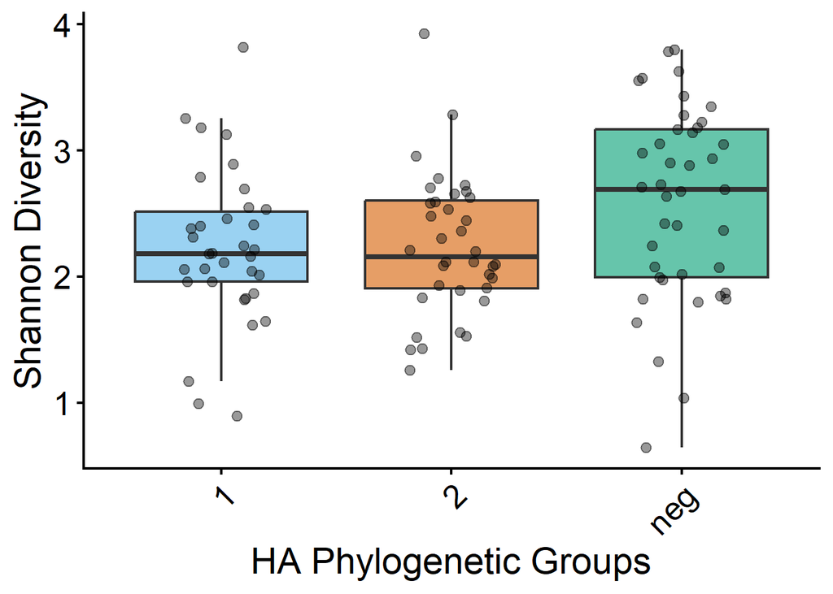

```r
p_formatted_HA_group = pdata_HA_group_shannon %>% ggplot(aes(ha_group,value,
                                                             fill = ha_group)) +
  geom_boxplot(outlier.shape = NA, alpha = 0.6) +
  geom_jitter(height= 0, width = 0.20, size = 2.5, alpha= 0.4) +
theme_classic(base_size=16)+
  ylab("Shannon Diversity") + xlab("HA Phylogenetic Groups") +
  theme(axis.text.x = element_text(angle = 45, vjust=1, hjust=1, size=20),
        legend.position = "none", axis.text.y = element_text(size=20),
         axis.title.x = element_text(size = 22),
  axis.title.y = element_text(size = 22)) +
  scale_fill_manual(values = c(
  "1" = "#56B4E9",
  "2" = "#D55E00",
  "neg" = "#009E73"
))

p_formatted_HA_group
```

Statistical analysis of the shannon diversity metric between HA phylogenetic groups

```r
df_HA_group_shannon <- data.frame(ha_group = as.factor(pdata_HA_group_shannon$ha_group), value = pdata_HA_group_shannon$value)
#Kruskal-Wallis and Dunn's test as post-hoc
res_sig_group_HA <-dunn.test(df_HA_group_shannon$value, df_HA_group_shannon$ha_group, kw=TRUE, method = "bh")
```

```
##   Kruskal-Wallis rank sum test
##
## data: x and group
## Kruskal-Wallis chi-squared = 6.461, df = 2, p-value = 0.04
##
##
##                    Dunn's Pairwise Comparison of x by group
##                              (Benjamini-Hochberg)
## Col Mean-│
## Row Mean │          1          2
## ─────────┼──────────────────────
##        2 │   0.022714
##          │     0.4909
##          │
##      neg │  -2.142996  -2.200080
##          │     0.0241*    0.0417*
##
## FDR = 0.05
## Reject Ho if p ≤ FDR/2 with stopping rule, where p = Pr(Z ≥ |z|)
```

```r
#Two significant groups
```

Generating a boxplot with significance bars.

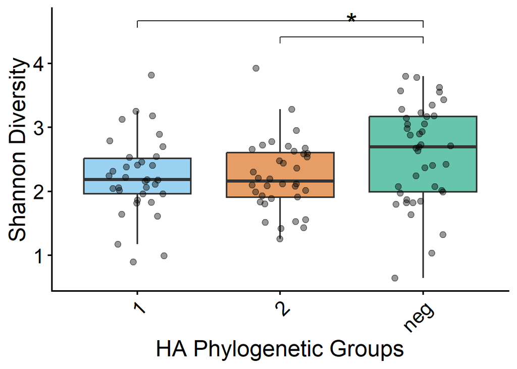

```r
P_signif_group_HA <- p_formatted_HA_group + geom_signif(
    comparison = list(c("1", "neg"), c("2","neg")),
    y_position = c(4.5,4.25),
    annotations = c("*","*"),
    textsize= 10
  )
P_signif_group_HA
```

```r
ggsave("Inf_HA_Group_Shannon.png", P_signif_group_HA, width =6, height = 9, dpi = 300)
```

## NA Phylogenetic Groups

Shannon diversity calculation but grouped by NA phylogenetic groups.

```r
set.seed(360)
p_NA_group_shannon = plot_richness(psrare, x="na_group",
                        measures = c("Shannon"),
                  color= "na_group")

pdata_NA_group_shannon = p_NA_group_shannon$data
```

Generating the initial boxplot without significance annotations.

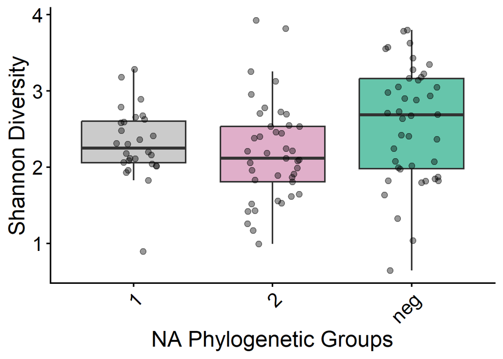

```r
p_formatted_NA_group = pdata_NA_group_shannon %>% ggplot(aes(na_group,value,
                                                             fill = na_group)) +
  geom_boxplot(outlier.shape = NA, alpha = 0.6) +
  geom_jitter(height= 0, width = 0.20, size = 2.5, alpha= 0.4) +
theme_classic(base_size=16)+
  ylab("Shannon Diversity") + xlab("NA Phylogenetic Groups") +
theme(axis.text.x = element_text(angle = 45, vjust=1, hjust=1, size=20),
        legend.position = "none", axis.text.y = element_text(size=20),
         axis.title.x = element_text(size = 22),
  axis.title.y = element_text(size = 22)) +
 scale_fill_manual(values = c(
  "1" = "darkgrey",
  "2" = "#CC79A7",
  "neg" = "#009E73"
))
p_formatted_NA_group
```

Statistical analysis of the shannon diversity metric between NA phylogenetic groups

```r
df_NA_group_shannon <- data.frame(na_group = as.factor(pdata_NA_group_shannon$na_group), value = pdata_NA_group_shannon$value)
#Kruskal-Wallis and Dunn's test as post-hoc
res_sig_group_NA <-dunn.test(df_NA_group_shannon$value, df_NA_group_shannon$na_group, kw=TRUE, method = "bh")
```

```
##   Kruskal-Wallis rank sum test
##
## data: x and group
## Kruskal-Wallis chi-squared = 6.2995, df = 2, p-value = 0.04
##
##
##                    Dunn's Pairwise Comparison of x by group
##                              (Benjamini-Hochberg)
## Col Mean-│
## Row Mean │          1          2
## ─────────┼──────────────────────
##        2 │   1.008400
##          │     0.1566
##          │
##      neg │  -1.241593  -2.505823
##          │     0.1608     0.0183*
##
## FDR = 0.05
## Reject Ho if p ≤ FDR/2 with stopping rule, where p = Pr(Z ≥ |z|)
```

Generating a boxplot with significance bars.

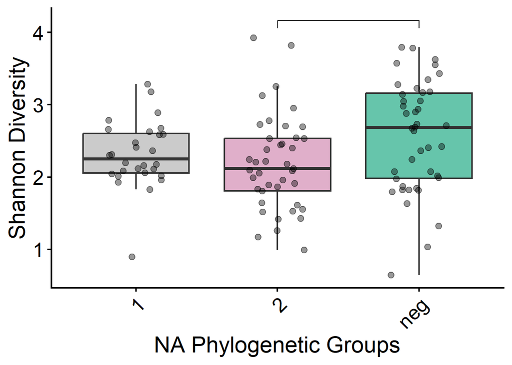

```r
P_signif_group_NA <- p_formatted_NA_group + geom_signif(
    comparison = list( c("2","neg")),
    y_position = c(4),
    annotations = c("*"),
    textsize = 10
  )
P_signif_group_NA
```

```r
ggsave("Inf_NA_Group_Shannon.png", P_signif_group_NA, width =6, height = 9, dpi = 300)
```

### Faith’s Diversity

Calculating the Faith’s PD values for each sample.

```r
#Adapted from MICB 305
#Taxa converted from columns to rows
otu = as(otu_table(psrare), "matrix")
if(taxa_are_rows(psrare)==TRUE) otu <- t(otu)

# Extract your phyloseq object's tree
tree_faith = phy_tree(psrare)

#Check that all the ASV names match between OTU table and tree
stopifnot(all(colnames(otu) %in% tree_faith$tip.label))

#Remove any unmatched tips
tree_faith = drop.tip(tree_faith, setdiff(tree_faith$tip.label, colnames(otu)))
#Reorder to match
tree_faith = keep.tip(tree_faith, colnames(otu))

#Rooting the tree
if(!is.rooted(tree_faith)) tree_faith <- root(tree_faith, outgroup=tree_faith$tip.label[1], resolve.root=TRUE)

# Calculate Faith's PD for each sample
#    1. Convert reads to presence/absence and pull into a matrix
otu_pa = otu # Make a copy of your data, then...
otu_pa[otu_pa>0] = 1 #...convert to presence/absence (1 for present, 0 for absent)
#    2. Calculate metric
faith = pd(otu_pa, tree_faith, include.root = TRUE) %>% select(-SR)

#Merging phyloseq data with the Faith's PD data.

metadata_rarefied = data.frame(sample_data(psrare))

faith_metadata = merge(metadata_rarefied, faith, by= "row.names")
```

## HA_NA

Statistical testing for the Faith’s diversity metric between HA_NA subtypes.

```r
faith_HA_NA_df <- data.frame(HA_NA = as.factor(faith_metadata$HA_NA), value = faith_metadata$PD)

faith_HA_NA_sig <-dunn.test(faith_HA_NA_df$value, faith_HA_NA_df$HA_NA, kw=TRUE, method = "bh")
```

```
##   Kruskal-Wallis rank sum test
##
## data: x and group
## Kruskal-Wallis chi-squared = 17.3563, df = 12, p-value = 0.14
##
##
##                    Dunn's Pairwise Comparison of x by group
##                              (Benjamini-Hochberg)
## Col Mean-│
## Row Mean │       H2N3   H3.4N2.8       H3N8       H4N1       H4N2     H4N2.6
## ─────────┼──────────────────────────────────────────────────────────────────
## H3.4N2.8 │  -1.083791
##          │     0.3620
##          │
##     H3N8 │  -0.401176   0.922120
##          │     0.4401     0.4213
##          │
##     H4N1 │   0.234333   0.988593   0.416441
##          │     0.4539     0.3935     0.4401
##          │
##     H4N2 │   1.218265   1.724977   1.495414   0.583448
##          │     0.3626     0.3663     0.3755     0.4547
##          │
##   H4N2.6 │   0.497958   1.186311   0.684153   0.197718  -0.355142
##          │     0.4730     0.3532     0.4187     0.4632     0.4269
##          │
##     H4N6 │  -0.093776   1.078072   0.377835  -0.280618  -1.342165  -0.552356
##          │     0.4687     0.3535     0.4299     0.4468     0.3334     0.4529
##          │
##     H4N8 │   0.471586   1.242998   0.727498   0.101469  -0.590301  -0.126836
##          │     0.4438     0.3626     0.4441     0.4717     0.4605     0.4738
##          │
##     H4N9 │  -1.728207  -0.483312  -1.576528  -1.471905  -2.283058  -1.669624
##          │     0.4093     0.4628     0.3734     0.3236     0.4373     0.3368
##          │
##     H5N1 │  -0.479580   0.799794  -0.161287  -0.476473  -1.477931  -0.731727
##          │     0.4561     0.4467     0.4723     0.4494     0.3399     0.4527
##          │
##     H5N2 │   0.261372   1.216874   0.721996  -0.121687  -1.094922  -0.389399
##          │     0.4487     0.3489     0.4265     0.4696     0.3679     0.4315
```

[output cut: 14 more lines]

```
##          │
##     H5N1 │  -0.458374  -0.772386   1.423748
##          │     0.4425     0.4515     0.3348
##          │
##     H5N2 │   0.417766  -0.327007   1.871282   0.732075
##          │     0.4546     0.4329     0.4782     0.4641
##          │
##     H5N5 │  -0.374658  -0.725977   1.567037   0.153152  -0.711707
##          │     0.4247     0.4344     0.3513     0.4692     0.4225
##          │
##      neg │  -2.130237  -1.418955   1.164217  -0.804961  -2.285801  -1.318987
##          │     0.3232     0.3200     0.3403     0.4559     0.8684     0.3318
##
## FDR = 0.05
## Reject Ho if p ≤ FDR/2 with stopping rule, where p = Pr(Z ≥ |z|)
```

## NA Subtype

Statistical testing for the Faith’s diversity metric between NA subtypes.

```r
faith_NA_df <- data.frame(na_subtype = as.factor(faith_metadata$na_subtype),
                                                 value = faith_metadata$PD)
faith_NA_sig <- dunn.test(faith_NA_df$value, faith_NA_df$na_subtype, kw=TRUE, method = "bh")
```

```
##   Kruskal-Wallis rank sum test
##
## data: x and group
## Kruskal-Wallis chi-squared = 16.15, df = 9, p-value = 0.06
##
##
##                    Dunn's Pairwise Comparison of x by group
##                              (Benjamini-Hochberg)
## Col Mean-│
## Row Mean │          1          2        2.6        2.8          3          5
## ─────────┼──────────────────────────────────────────────────────────────────
##        2 │   0.886131
##          │     0.3521
##          │
##      2.6 │   0.661568   0.267142
##          │     0.4235     0.4800
##          │
##      2.8 │  -0.891678  -1.349528  -1.186311
##          │     0.3645     0.3066     0.3785
##          │
##        3 │   0.345165  -0.558435  -0.497958   1.083791
##          │     0.4693     0.4324     0.4349     0.3481
##          │
##        5 │   0.189944  -0.777713  -0.582933   1.008671  -0.177606
##          │     0.4900     0.3779     0.4344     0.3355     0.4832
##          │
##        6 │   0.307891  -0.790211  -0.552356   1.078072  -0.093776   0.111818
##          │     0.4739     0.3865     0.4215     0.3328     0.4732     0.4767
##          │
##        8 │   0.174321  -0.895675  -0.605675   1.010994  -0.223374  -0.032455
##          │     0.4728     0.3788     0.4377     0.3510     0.4874     0.4871
##          │
##        9 │  -1.524483  -2.008172  -1.669624  -0.483312  -1.728207  -1.657102
##          │     0.2389     0.3347     0.2375     0.4288     0.3148     0.2194
##          │
##      neg │  -1.098311  -2.888271  -1.179953   0.478122  -1.725829  -1.577532
##          │     0.3601     0.0872     0.3570     0.4186     0.2712     0.2346
## Col Mean-│
## Row Mean │          6          8          9
## ─────────┼─────────────────────────────────
##        8 │  -0.163307
##          │     0.4662
##          │
##        9 │  -1.742321  -1.669638
##          │     0.3665     0.2672
##          │
##      neg │  -2.176121  -1.781369   1.153634
##          │     0.3324     0.4210     0.3497
##
## FDR = 0.05
## Reject Ho if p ≤ FDR/2 with stopping rule, where p = Pr(Z ≥ |z|)
```

## HA Subtype

Statistical testing for the Faith’s diversity metric between HA subtypes.

```r
faith_HA_df <- data.frame(ha_subtype = as.factor(faith_metadata$ha_subtype),
                                                 value = faith_metadata$PD)
faith_HA_sig <- dunn.test(faith_HA_df$value, faith_HA_df$ha_subtype, kw=TRUE, method = "bh")
```

```
##   Kruskal-Wallis rank sum test
##
## data: x and group
## Kruskal-Wallis chi-squared = 10.7785, df = 5, p-value = 0.06
##
##
##                    Dunn's Pairwise Comparison of x by group
##                              (Benjamini-Hochberg)
## Col Mean-│
## Row Mean │          2          3        3.4          4          5
## ─────────┼───────────────────────────────────────────────────────
##        3 │  -0.401176
##          │     0.4693
##          │
##      3.4 │  -1.083791  -0.922120
##          │     0.3481     0.3342
##          │
##        4 │   0.095127   0.618623   1.164359
##          │     0.4621     0.4468     0.3664
##          │
##        5 │  -0.183244   0.312289   1.055344  -0.398920
##          │     0.4578     0.4355     0.3121     0.4312
##          │
##      neg │  -1.693904  -1.379149   0.488896  -2.698465  -2.315991
##          │     0.2257     0.3147     0.4687     0.0522     0.0771
##
## FDR = 0.05
## Reject Ho if p ≤ FDR/2 with stopping rule, where p = Pr(Z ≥ |z|)
```

## NA Subtype Aggregated

Statistical testing for the Faith’s diversity metric between NA aggregated subtypes.

```r
faith_NA_aggr_df <- data.frame(na_aggr = as.factor(faith_metadata$na_aggr),
                                                 value = faith_metadata$PD)
faith_NA_aggr_sig <- dunn.test(faith_NA_aggr_df$value, faith_NA_aggr_df$na_aggr, kw=TRUE, method = "bh")
```

```
##   Kruskal-Wallis rank sum test
##
## data: x and group
## Kruskal-Wallis chi-squared = 14.1959, df = 7, p-value = 0.05
##
##
##                    Dunn's Pairwise Comparison of x by group
##                              (Benjamini-Hochberg)
## Col Mean-│
## Row Mean │          1          2          3          5          6          8
## ─────────┼──────────────────────────────────────────────────────────────────
##        2 │   0.750375
##          │     0.4530
##          │
##        3 │   0.345165  -0.402137
##          │     0.5379     0.5348
##          │
##        5 │   0.189944  -0.622232  -0.177606
##          │     0.5405     0.4671     0.5229
##          │
##        6 │   0.307891  -0.610482  -0.093776   0.111818
##          │     0.5307     0.4460     0.4798     0.4905
##          │
##        8 │   0.174321  -0.729496  -0.223374  -0.032455  -0.163307
##          │     0.5026     0.4347     0.5488     0.4871     0.4874
##          │
##        9 │  -1.524483  -1.945298  -1.728207  -1.657102  -1.742321  -1.669638
##          │     0.1621     0.2414     0.1959     0.1517     0.2281     0.1662
##          │
##      neg │  -1.098311  -2.798632  -1.725829  -1.577532  -2.176121  -1.781369
##          │     0.2930     0.0718     0.1688     0.1605     0.2068     0.2620
## Col Mean-│
## Row Mean │          9
## ─────────┼───────────
##      neg │   1.153634
##          │     0.2901
##
## FDR = 0.05
## Reject Ho if p ≤ FDR/2 with stopping rule, where p = Pr(Z ≥ |z|)
```

```r
#Kruskal Wallis of 0.05 but no observed significant pairs
```

## HA Subtype Aggregated

Statistical testing for the Faith’s diversity metric between HA aggregated subtypes.

```r
faith_HA_aggr_df <- data.frame(ha_aggr = as.factor(faith_metadata$ha_aggr),
                                                 value = faith_metadata$PD)
faith_HA_aggr_sig <- dunn.test(faith_HA_aggr_df$value, faith_HA_aggr_df$ha_aggr, kw=TRUE, method = "bh")
```

```
##   Kruskal-Wallis rank sum test
##
## data: x and group
## Kruskal-Wallis chi-squared = 9.9282, df = 4, p-value = 0.04
##
##
##                    Dunn's Pairwise Comparison of x by group
##                              (Benjamini-Hochberg)
## Col Mean-│
## Row Mean │          2          3          4          5
## ─────────┼────────────────────────────────────────────
##        3 │  -0.584247
##          │     0.4659
##          │
##        4 │   0.095127   0.864103
##          │     0.4621     0.3875
##          │
##        5 │  -0.183244   0.551832  -0.398920
##          │     0.4748     0.4150     0.4312
##          │
##      neg │  -1.693904  -1.182283  -2.698465  -2.315991
##          │     0.1505     0.2964     0.0348     0.0514
##
## FDR = 0.05
## Reject Ho if p ≤ FDR/2 with stopping rule, where p = Pr(Z ≥ |z|)
```

```r
#one significant group
```

## HA Phylogenetic Groups

Initial boxplot of the Faith’s diversity metric grouped by HA phylogenetic groups.

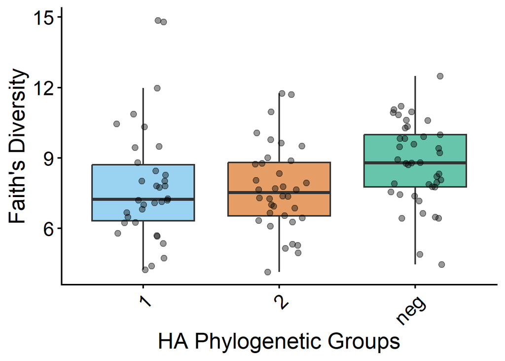

```r
faith_formatted_HA_group = faith_metadata %>% ggplot(aes(ha_group,PD,
                                                             fill = ha_group)) +
  geom_boxplot(outlier.shape = NA, alpha = 0.6) +
  geom_jitter(height= 0, width = 0.20, size = 2.5, alpha= 0.4) +
theme_classic(base_size=16)+
  ylab("Faith's Diversity") + xlab("HA Phylogenetic Groups") +
  theme(axis.text.x = element_text(angle = 45, vjust=1, hjust=1, size=20),
        legend.position = "none", axis.text.y = element_text(size=20),
         axis.title.x = element_text(size = 22),
  axis.title.y = element_text(size = 22)) +
   scale_fill_manual(values = c(
  "1" = "#56B4E9",
  "2" = "#D55E00",
  "neg" = "#009E73"
))
faith_formatted_HA_group
```

Statistical testing for the Faith’s diversity metric between HA phylogenetic groups.

```r
faith_HA_group_df <- data.frame(ha_group = as.factor(faith_metadata$ha_group),
                                                 value = faith_metadata$PD)
faith_HA_group_sig <- dunn.test(faith_HA_group_df$value, faith_HA_group_df$ha_group, kw=TRUE, method = "bh")
```

```
##   Kruskal-Wallis rank sum test
##
## data: x and group
## Kruskal-Wallis chi-squared = 9.148, df = 2, p-value = 0.01
##
##
##                    Dunn's Pairwise Comparison of x by group
##                              (Benjamini-Hochberg)
## Col Mean-│
## Row Mean │          1          2
## ─────────┼──────────────────────
##        2 │  -0.026535
##          │     0.4894
##          │
##      neg │  -2.578359  -2.590644
##          │     0.0074*    0.0144*
##
## FDR = 0.05
## Reject Ho if p ≤ FDR/2 with stopping rule, where p = Pr(Z ≥ |z|)
```

Significant comparisons mapped onto the initial boxplot.

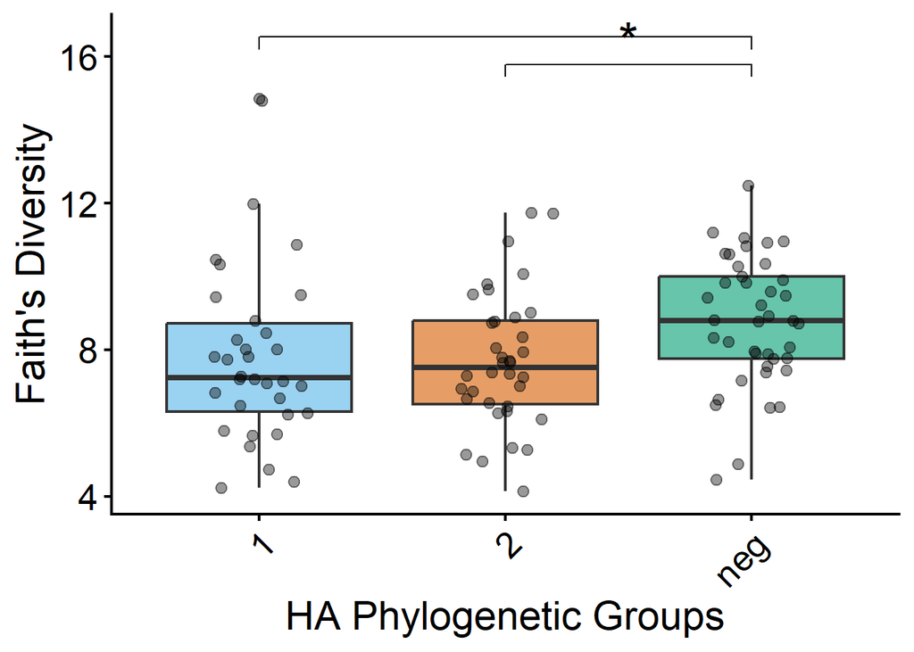

```r
P_faith_group_HA <- faith_formatted_HA_group + geom_signif(
    comparison = list(c("1", "neg"), c("2","neg")),
    y_position = c(16,15.25),
    annotations = c("**","*"),
    textsize = 10
  )
P_faith_group_HA
```

```r
ggsave("Inf_HA_Group_Faith.png", P_faith_group_HA, width= 6, height =9, dpi=300)
```

## NA Phylogenetic Group

Initial boxplot of the Faith’s diversity metric grouped by NA phylogenetic groups.

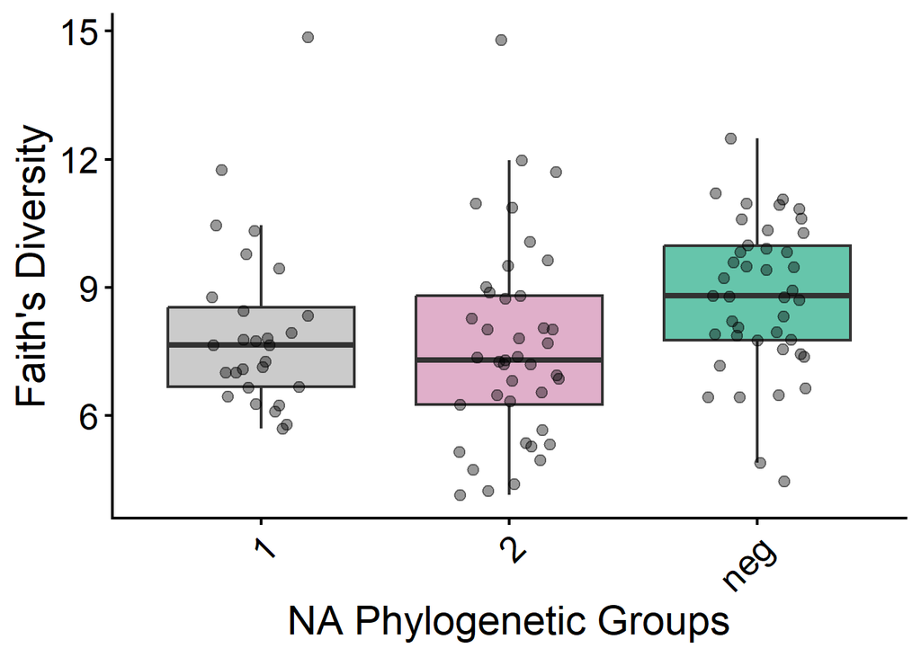

```r
faith_formatted_NA_group = faith_metadata %>% ggplot(aes(na_group,PD,
                                                             fill = na_group)) +
  geom_boxplot(outlier.shape = NA, alpha = 0.6) +
  geom_jitter(height= 0, width = 0.20, size = 2.5, alpha= 0.4) +
theme_classic(base_size=16)+
  ylab("Faith's Diversity") + xlab("NA Phylogenetic Groups") +
   theme(axis.text.x = element_text(angle = 45, vjust=1, hjust=1, size=20),
        legend.position = "none", axis.text.y = element_text(size=20),
         axis.title.x = element_text(size = 22),
  axis.title.y = element_text(size = 22)) +
  scale_fill_manual(values = c(
  "1" = "darkgrey",
  "2" = "#CC79A7",
  "neg" = "#009E73"
))
faith_formatted_NA_group
```

Statistical testing for the Faith’s diversity metric between NA phylogenetic groups.

```r
faith_NA_group_df <- data.frame(na_group = as.factor(faith_metadata$na_group),
                                                 value = faith_metadata$PD)
faith_NA_group_sig <- dunn.test(faith_NA_group_df$value, faith_NA_group_df$na_group, kw=TRUE, method = "bh")
```

```
##   Kruskal-Wallis rank sum test
##
## data: x and group
## Kruskal-Wallis chi-squared = 10.3031, df = 2, p-value = 0.01
##
##
##                    Dunn's Pairwise Comparison of x by group
##                              (Benjamini-Hochberg)
## Col Mean-│
## Row Mean │          1          2
## ─────────┼──────────────────────
##        2 │   0.478535
##          │     0.3161
##          │
##      neg │  -2.260336  -3.046236
##          │     0.0179*    0.0035*
##
## FDR = 0.05
## Reject Ho if p ≤ FDR/2 with stopping rule, where p = Pr(Z ≥ |z|)
```

Significant comparisons mapped onto the initial boxplot.

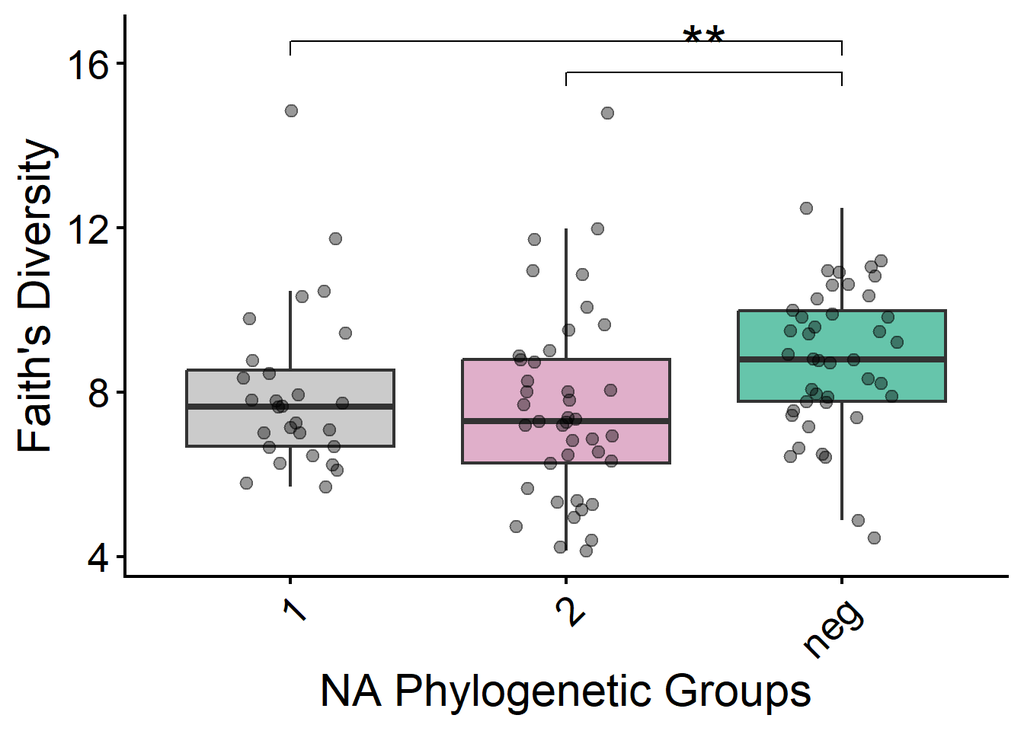

```r
P_faith_group_NA <- faith_formatted_NA_group + geom_signif(
    comparison = list(c("1", "neg"), c("2","neg")),
    y_position = c(16,15.25),
    annotations = c("*","**"),
    textsize = 10
  )
P_faith_group_NA
```

```r
ggsave("Inf_NA_Group_Faith.png", P_faith_group_NA, width= 6, height =9, dpi=300)
```